# Length data

#Background: The following .Rmd includes code for accessing and plotting length data from the CCTD (California Current Trophic Database) via ERDDAP

#load packages

```r
library(tidyverse) #ggplot, dplyr etc
library(rerddap) # accessing erddap
library(sf) #plotting spatial objects
```

# Download LENGTH data from ERDDAP

Whereas the data accessed for the freq of occurance analysis, available at Meso_diet.Rmd had length data available for predators, there wasn’t length data available for prey in the format we selected. Thus, the following code re-downloads data from the CCTD via ERDDAP in the format that includes prey length information.

NOTE: we selected distinct=FALSE instead of true (as in meso_diet.Rmd) and updatedsoem of the length input fields if true- will give individual predator with sum of prey per predator if false- will list indivdiual prey with length data available

```r
# Get info about dataset: food habit data
rerddap::browse("SWFSC-CCTD", url = "https://oceanview.pfeg.noaa.gov/erddap/") #background info on data field, acknowledgements etc

cctd_info <- rerddap::info(datasetid = "SWFSC-CCTD", url = "https://oceanview.pfeg.noaa.gov/erddap/") # load info on dataset
cctd_info  # print list of variables

# select for variables we are interested in: DO NOT include fields for prey size (as this may present format issue):
food_habits_data_length <- rerddap::tabledap(cctd_info, fields = c("data_source",
                                                                   "predator_taxa",
                                                                  "includes_prey_size_information",
                                                                   "latitude",
                                                                   "longitude",
                                                                  "predator_scientific_name",
                                                                  "predator_common_name",
                                                                  "prey_scientific_name",
                                                                  "prey_common_name",
                                                                  "prey_number",
                                                                  "prey_weight",
                                                                  "prey_volume",
                                                                  "prey_measurement_back_calc",
                                                                  "prey_length_back_calc",
                                                                  "prey_measurement_1",
                                                                  "prey_length_1",
                                                                  "prey_measurement_2",
                                                                  "prey_length_2",
                                                                  "number_measured",
                                                                  "prey_length_min",
                                                                  "prey_length_max",
                                                                  "prey_length_mean",
                                                                  "prey_weight_indiv",
                                                                  "prey_number_corrected_indiv",
                                                                  "prey_size_comments")) #download ALL fields
```

Of note: prey_measurement_1: describes the type of measurement and prey_length_1: the actual value of that measurement

however, there are in some cases of alternative measurements within the database prey_measurement_2 prey_length_2

# select for mesopelagic fish prey

```r
meso_spp # our list of mesopelagic fish spp.
```

```
 [1] "Anotopterus nikparini"        "Arctozenus risso"             "Argyropelecus affinis"        "Bathylagidae"
 [5] "Bathylagoides wesethi"        "Bathylagus pacificus"         "Benthalbella"                 "Benthalbella dentata"
 [9] "Ceratoscopelus townsendi"     "Chauliodontinae"              "Chauliodus macouni"           "Diaphus theta"
[13] "Diogenichthys laternatus"     "Gonostomatidae"               "Idiacanthus"                  "Lampadena urophaos"
[17] "Lampanyctus"                  "Lampanyctus jordani"          "Lampanyctus ritteri"          "Lepidopus caudatus"
[21] "Lestidiops ringens"           "Leuroglossus"                 "Leuroglossus schmidti"        "Leuroglossus stilbius"
[25] "Lipolagus ochotensis"         "Lycodapus fierasfer"          "Lycodapus mandibularis"       "Macropinna microstoma"
[29] "Magnisudis atlantica"         "Melamphaes"                   "Melamphaes lugubris"          "Melanostigma pammelas"
[33] "Myctophidae"                  "Myctophum nitidulum"          "Nannobrachium regale"         "Nansenia"
[37] "Nansenia candida"             "Nansenia crassa"              "Nemichthyidae"                "Nemichthys scolopaceus"
[41] "Notolepis"                    "Notoscopelus resplendens"     "Paralepididae"                "Parvilux ingens"
[45] "Poromitra crassiceps"         "Protomyctophum"               "Protomyctophum crockeri"      "Pseudobathylagus milleri"
[49] "Rosenblattichthys volucris"   "Sagamichthys abei"            "Scopelarchidae"               "Scopelogadus bispinosus"
[53] "Stemonosudis macrura"         "Stenobrachius"                "Stenobrachius leucopsarus"    "Stomiidae"
[57] "Symbolophorus californiensis" "Tactostoma"                   "Tactostoma macropus"          "Tarletonbeania crenularis"
[61] "Tetragonurus cuvieri"         "Triphoturus mexicanus"
```

```r
coastal_pelagic_fish # CPS forage fish
```

```
[1] "Sardinops sagax"             "Scomber japonicus"           "Engraulis mordax"            "Trachurus symmetricus"       "Clupea pallasii pallasii"
[6] "Atherinopsis californiensis"
```

```r
# select for mesopelagic fish or CPS fish lengths specifically
lengths_meso_cps <- food_habits_data_length |> #of all available length data
                    filter(prey_scientific_name %in% meso_spp| prey_scientific_name %in% coastal_pelagic_fish) |>  # filter for mesopelagic +cps
                    mutate(prey_type= ifelse(prey_scientific_name %in% meso_spp, "mesopelagic", "cps_fish")) #create a column identifying CPS or meso

# what types of measurements do we have?
unique(lengths_meso_cps$prey_measurement_2)
```

```
[1] "FL" ""
```

```r
# the only measurements available in prey_measurement_2 is FL or "" blank so not obtaining any extra SLs here.


# Hmm looks like NA, SL, TL, FL and not sure what PTL or LA is?!

# Group by measurement type
lengths_meso_cps |>
  group_by(prey_measurement_1) |>
  summarise(n=n())
```

| prey_measurement_1 | n |
| --- | --- |
|  | 46702 |
| FL | 136 |
| LA | 4 |
| PTL | 10 |
| SL | 953 |
| TL | 1449 |

```r
# of these measurements, there are 1449 total lengths and 953 SLs

lengths_meso_cps |>
  group_by(prey_common_name, prey_scientific_name, prey_measurement_1) |>
  filter(prey_measurement_1 !="") |> # remove blanks with no info
  summarise(n=n()) |>  # total number of records of prey measurements per spp and measurement type
  filter(prey_measurement_1=="TL")
```

| prey_common_name | prey_scientific_name | prey_measurement_1 | n |
| --- | --- | --- | --- |
| Northern Anchovy | Engraulis mordax | TL | 1210 |
| Northern Lampfish | Stenobrachius leucopsarus | TL | 3 |
| Pacific Herring | Clupea pallasii pallasii | TL | 135 |
| Pacific Sardine | Sardinops sagax | TL | 89 |
| myctophid | Myctophidae | TL | 7 |
| snipe eel | Nemichthyidae | TL | 5 |

As there is some descrepency in the type of length measurements made per indivdual, the following is the information available for converting between measurement type derived from fishbase.org

TO CONVERT TL TO SL:

TO CONVERT FL to SL:

Rosenblattichthys volucris: no length info Magnisudis atlantica: no FL conversation (only SL to TL) Engraulis mordax: SL =0 + 0.942 *FL Leuroglossus schmidti: no FL to SL conversion (only FL and SL to TL): Convert from FL to TL: TL= 0 + 1.039FL Convert from SL to TL: TL= 0 + 1.119SL so SL= 0.928 FL Scomber japonicus: SL= 2.330+ 0.860 FL SL= 0.000 + 0.903 FL (take mean of two equations?) SL= 1.165 + 0.8815 FL Trachurus symmetricus:SL= 0+ 0.954FL

Sardinops sagax: SL= 0+ 0.941FL SL= 0+ 0.942FL SL= 0+ 0.944FL Combined: SL=0 + 0.942FL Lestidiops ringens: NO length conversion available

Tetragonurus cuvieri: two equations for FL to TL and SL to TL so can combine convert from FL to TL: TL 0.000 1.053 FL  
convert from SL to TL: TL 0.000 1.138 SL so: SL= 0+ 0.925FL Arctozenus risso: convert FL to TL: TL 0.000 1.047 FL convrt SL to TL: TL 0.000 1.065 SL so: SL= 0+ 0.983FL

Lampadena urophaos: Only SL to TL so can’t calculate

https://www.fishbase.de/manual/english/PDF/FB_Book_CBinohlan_Length-Length_RF_JG.pdf For fishbase values per spp Search for specific spp

# Extract length info - combine different measurements

NOTE: unique(lengths_meso_cps$prey_measurement_back_calc) # the only backcalculated values are SL or “” blank So we can substitute the back-calculated value of SL

```r
# Find available SL measurements per prey item
# First look to length measurement 1, if not, use backcalculated values
# then use FL or TL measurements and convert

lengths_meso_cps$length<- ifelse(lengths_meso_cps$prey_measurement_1=="SL", lengths_meso_cps$prey_length_1, lengths_meso_cps$prey_length_back_calc)
lengths_meso_cps$length <- as.numeric(lengths_meso_cps$length) #convert to numeric

#list the type of measurement used-- if measured SL, list otherwise, backcalcualted value
lengths_meso_cps$length_type <- ifelse(lengths_meso_cps$prey_measurement_1=="SL", lengths_meso_cps$prey_measurement_1, paste0(lengths_meso_cps$prey_measurement_back_calc, "_bc" ))

#convert to a dataframe to avoid some weirdness below- was imported as tabledap
lengths_meso_cps <- as.data.frame(lengths_meso_cps)

# Convert missing (NaN) values from our length columns (which includes SL measured or if absent, SL backcalculated)- easier to recognize
lengths_meso_cps$length[is.nan(lengths_meso_cps$length)]<-NA
```

# OKAY, now to fill in missing length values for those prey items lacking SL

So far I created the col “length”: which includes either a measured SL in mm or a backcalculated standard length Next, for those rows that don’t have an associated SL value (ie NA), estimate a SL from either TL or FL estimates

```r
# filter for those values that are missing SL measurement-- still 23,292
  lengths_missing <- lengths_meso_cps |>
  filter(is.na(length))
```

# Would like to provide an SL estimate in those cases where either TL or FL were measured (and we have a conversion from fishbase)

Starting with FL

# ESTIMATE SL FROM TL

# ESTIMATE SL FROM FL

```r
# convert lengths from character to numeric so we can do math on them
lengths_meso_cps$prey_length_1 <- as.numeric(lengths_meso_cps$prey_length_1)
lengths_meso_cps$prey_length_2 <- as.numeric(lengths_meso_cps$prey_length_2)

# CONVERT TL estimates to SL (for taxa with available conversions):This is awkward coding, I am aware, but best I can do

# Anchovy
lengths_meso_cps$length <- ifelse(lengths_meso_cps$prey_measurement_1=="TL"& lengths_meso_cps$prey_common_name=="Northern Anchovy", lengths_meso_cps$prey_length_1*0.853, lengths_meso_cps$length)
#Northern Lampfish
lengths_meso_cps$length <- ifelse(lengths_meso_cps$prey_measurement_1=="TL"& lengths_meso_cps$prey_common_name=="Northern Lampfish", lengths_meso_cps$prey_length_1*0.843, lengths_meso_cps$length)
#Pacific Herring
lengths_meso_cps$length <- ifelse(lengths_meso_cps$prey_measurement_1=="TL"& lengths_meso_cps$prey_common_name=="Pacific Herring", lengths_meso_cps$prey_length_1*0.850, lengths_meso_cps$length)
#Pacific Sardine
lengths_meso_cps$length <- ifelse(lengths_meso_cps$prey_measurement_1=="TL"& lengths_meso_cps$prey_common_name=="Pacific Sardine", lengths_meso_cps$prey_length_1*0.850, lengths_meso_cps$length)




# CONVERT FL estimates to SL (for taxa with available conversions):for those missing SL info

# Anchovy
lengths_meso_cps$length <- ifelse(lengths_meso_cps$prey_measurement_1=="FL"& lengths_meso_cps$prey_scientific_name=="Engraulis mordax", lengths_meso_cps$prey_length_1*0.942, lengths_meso_cps$length)
# Leuroglossus schmidti
lengths_meso_cps$length <- ifelse(lengths_meso_cps$prey_measurement_1=="FL"& lengths_meso_cps$prey_scientific_name=="Leuroglossus schmidti", lengths_meso_cps$prey_length_1*0.928, lengths_meso_cps$length)
# Trachurus symmetricus:SL= 0+ 0.954FL
lengths_meso_cps$length <- ifelse(lengths_meso_cps$prey_measurement_1=="FL"& lengths_meso_cps$prey_scientific_name=="Trachurus symmetricus", lengths_meso_cps$prey_length_1*0.954, lengths_meso_cps$length)
# Sardinops sagax: SL=0 + 0.942FL
lengths_meso_cps$length <- ifelse(lengths_meso_cps$prey_measurement_1=="FL"& lengths_meso_cps$prey_scientific_name=="Sardinops sagax", lengths_meso_cps$prey_length_1*0.942, lengths_meso_cps$length)
# Tetragonurus cuvieri: SL= 0+ 0.925FL
lengths_meso_cps$length <- ifelse(lengths_meso_cps$prey_measurement_1=="FL"& lengths_meso_cps$prey_scientific_name=="Tetragonurus cuvieri", lengths_meso_cps$prey_length_1*0.925, lengths_meso_cps$length)
# Arctozenus risso: SL= 0+ 0.983FL
lengths_meso_cps$length <- ifelse(lengths_meso_cps$prey_measurement_1=="FL"& lengths_meso_cps$prey_scientific_name=="Arctozenus risso", lengths_meso_cps$prey_length_1*0.983, lengths_meso_cps$length)
# Scomber japonicus: SL= 11.65 + 0.8815 FL
lengths_meso_cps$length <- ifelse(lengths_meso_cps$prey_measurement_1=="FL"& lengths_meso_cps$prey_scientific_name=="Scomber japonicus", lengths_meso_cps$prey_length_1*0.8815+11.65, lengths_meso_cps$length)



# Checked output for each species as I went and all looks good!

# Update length_type column- type of measurement

# Update the length_type columns (how SL value was obtained either: SL measured SL, SL_bc: backcalculated or SL_est_TL or SL_est_FL)
# if length_type value was _bc (which means no measured SL or backcalculated SL),
lengths_meso_cps$length_type <- ifelse(lengths_meso_cps$length_type=="_bc", paste0("SL_est_", lengths_meso_cps$prey_measurement_1), lengths_meso_cps$length_type)
# THEN remove those values that we are not converting from (ie if not TL or FL)
lengths_meso_cps$length_type[lengths_meso_cps$length_type %in% c("SL_est_", "SL_est_PTL", "SL_est_LA")]<- NA
# check that updated correctly:
unique(lengths_meso_cps$length_type) # looks good: options are "SL" "Sl_bc" "NA" "SL_est_TL" or "SL_est_FL"
```

```
[1] "SL"        "SL_bc"     NA          "SL_est_TL" "SL_est_FL"
```

We now have a fully updated df with the column length (SL in mm) and length_type (either measured, backcalcualted or estimated from a different length measurement)

# Missing values

Length availability: have a total of 27,460 records of length for both cps fish and mesopealgic fish prey

```r
# check for additional length measures

lengths_meso_cps |>
  filter(is.na(length) & prey_measurement_2=="FL")
```

| data_source | predator_taxa | includes_prey_size_information | latitude | longitude | predator_scientific_name | predator_common_name | prey_scientific_name | prey_common_name | prey_number | prey_weight | prey_volume | prey_measurement_back_calc | prey_length_back_calc | prey_measurement_1 | prey_length_1 | prey_measurement_2 | prey_length_2 | number_measured | prey_length_min | prey_length_max | prey_length_mean | prey_weight_indiv | prey_number_corrected_indiv | prey_size_comments | prey_type | length | length_type |
| --- | --- | --- | --- | --- | --- | --- | --- | --- | --- | --- | --- | --- | --- | --- | --- | --- | --- | --- | --- | --- | --- | --- | --- | --- | --- | --- | --- |
| Kerim Aydin | Slope Groundfishes | yes | 41.01 | -124.6 | Anoplopoma fimbria | Sablefish | Chauliodus macouni | Pacific Viperfish | 1 | 34.23 | NaN |  | NaN | SL | NaN | FL | 205.0 | NaN | NaN | NaN | NaN | NaN | NaN |  | mesopelagic | NA | SL |
| Kerim Aydin | Slope Groundfishes | yes | 41.01 | -124.6 | Anoplopoma fimbria | Sablefish | Myctophidae | myctophid | 1 | 7.044 | NaN |  | NaN | SL | NaN | FL | 94.0 | NaN | NaN | NaN | NaN | NaN | NaN |  | mesopelagic | NA | SL |
| Kerim Aydin | Slope Groundfishes | yes | 39.64 | -124.0 | Merluccius productus | Pacific Hake | Leuroglossus schmidti | Northern Smoothtongue | 1 | 0.656 | NaN |  | NaN | SL | NaN | FL | 51.0 | NaN | NaN | NaN | NaN | NaN | NaN |  | mesopelagic | NA | SL |
| Kerim Aydin | Slope Groundfishes | yes | 39.64 | -124.0 | Merluccius productus | Pacific Hake | Stenobrachius leucopsarus | Northern Lampfish | 1 | 3.595 | NaN |  | NaN | SL | NaN | FL | 81.0 | NaN | NaN | NaN | NaN | NaN | NaN |  | mesopelagic | NA | SL |
| Kerim Aydin | Slope Groundfishes | yes | 38.97 | -124.03 | Merluccius productus | Pacific Hake | Bathylagus pacificus | Slender Blacksmelt | 1 | 33.908 | NaN |  | NaN | SL | NaN | FL | 140.0 | NaN | NaN | NaN | NaN | NaN | NaN |  | mesopelagic | NA | SL |
| Kerim Aydin | Slope Groundfishes | yes | 39.64 | -124.0 | Merluccius productus | Pacific Hake | Myctophidae | myctophid | 1 | 2.303 | NaN |  | NaN | SL | NaN | FL | 78.0 | NaN | NaN | NaN | NaN | NaN | NaN |  | mesopelagic | NA | SL |
| Kerim Aydin | Slope Groundfishes | yes | 38.97 | -124.03 | Merluccius productus | Pacific Hake | Myctophidae | myctophid | 1 | 2.63 | NaN |  | NaN | SL | NaN | FL | 72.0 | NaN | NaN | NaN | NaN | NaN | NaN |  | mesopelagic | NA | SL |
| Kerim Aydin | Slope Groundfishes | yes | 39.52 | -124.19 | Anoplopoma fimbria | Sablefish | Bathylagus pacificus | Slender Blacksmelt | 1 | 8.839 | NaN |  | NaN | SL | NaN | FL | 135.0 | NaN | NaN | NaN | NaN | NaN | NaN |  | mesopelagic | NA | SL |
| Kerim Aydin | Slope Groundfishes | yes | 45.85 | -124.88 | Sebastolobus alascanus | Shortspine Thornyhead | Clupea pallasii pallasii | Pacific Herring | 1 | 17.936 | NaN |  | NaN | SL | NaN | FL | 240.0 | NaN | NaN | NaN | NaN | NaN | NaN |  | cps_fish | NA | SL |
| Kerim Aydin | Slope Groundfishes | yes | 39.95 | -124.21 | Merluccius productus | Pacific Hake | Stenobrachius leucopsarus | Northern Lampfish | 1 | 1.31 | NaN |  | NaN | SL | NaN | FL | 60.0 | NaN | NaN | NaN | NaN | NaN | NaN |  | mesopelagic | NA | SL |

[output cut: 3 more lines]

```r
# Fill in these couple remaining length gaps: using the FL in prey_length_2 column when NA in length

#Northern smoothongue
lengths_meso_cps$length <- ifelse(is.na(lengths_meso_cps$length)& lengths_meso_cps$prey_measurement_2=="FL" & lengths_meso_cps$prey_common_name=="Northern Smoothtongue", lengths_meso_cps$prey_length_2*0.928, lengths_meso_cps$length)
# Northern Lampfish Stenobrachius leucopsarus: SL= 0.914 FL
lengths_meso_cps$length <- ifelse(is.na(lengths_meso_cps$length)& lengths_meso_cps$prey_measurement_2=="FL" & lengths_meso_cps$prey_common_name=="Northern Lampfish", lengths_meso_cps$prey_length_2*0.914, lengths_meso_cps$length)
# Slender Blacksmelt Bathylagus pacificus: 0.964 FL (combined from TL calculations)
lengths_meso_cps$length <- ifelse(is.na(lengths_meso_cps$length)& lengths_meso_cps$prey_measurement_2=="FL" & lengths_meso_cps$prey_common_name=="Slender Blacksmelt", lengths_meso_cps$prey_length_2*0.964, lengths_meso_cps$length)
# Pacific Herring Clupea pallasii pallasii: 0.926 FL
lengths_meso_cps$length <- ifelse(is.na(lengths_meso_cps$length)& lengths_meso_cps$prey_measurement_2=="FL" & lengths_meso_cps$prey_common_name=="Pacific Herring", lengths_meso_cps$prey_length_2*0.926, lengths_meso_cps$length)



# from 13 down to 6 - i feel like I have done everythign I can here to provide as much data as possible!!
```

# ESTIMATE SL FROM FL

For those species that didn’t have a measured, backcalculated SL but DID have prey_measurement_2 data available

Pacific Viperfish Chauliodus macouni: no length conversion available Northern Smoothtongue Leuroglossus schmidti: SL= 0.928 FL Northern Lampfish Stenobrachius leucopsarus: SL= 0.914 FL Slender Blacksmelt Bathylagus pacificus: 0.964 FL (combined from TL calculations) Pacific Herring Clupea pallasii pallasii: 0.926 FL Blue Lanternfish Tarletonbeania crenularis: no length conversion available on fishbase myctophid: generic, no taxa specific conversion available

# REMOVE those remaining records that still don’t have length data available (SL): measured SL, backcalculated SL or estimated SL from FL or TL

```r
lengths_meso_cps <- lengths_meso_cps |>
                  filter(!is.na(length))
```

Next: estiamte the mean length per family of mesopelagic fish - by first joining dfs

# JOIN prey FAMILY based on prey common name

```r
# JOIN prey FAMILY based on prey common name


lengths_meso_cps <- left_join(lengths_meso_cps, select(prey_taxonomy, family, prey_scientific_name), by="prey_scientific_name")
```

# FINALLY PLOT size frequency for mesopelagic and cps fish species – density plot

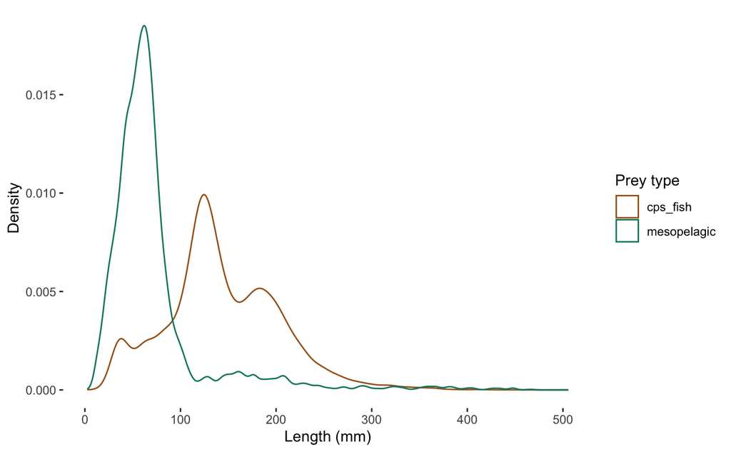

```r
# Plot of length distribution cps and meso
ggplot(data=lengths_meso_cps, aes(x=length, group=prey_type, color=prey_type))+
  geom_density()+
  scale_color_manual(values=c("#a6611a","#018571"))+
  labs(color="Prey type", x="Length (mm)", y="Density", size=2 )+
  theme(panel.background = element_blank(),
        legend.key =   element_blank())

ggsave("size_freq_meso_cps.pdf")
```

# IF we want to look at CPS eaten by the same species that also ate mesopelagic species, then we simply first select by predator species

```r
lengths_meso_cps_meso_preds <-lengths_meso_cps |>
                              filter(predator_scientific_name %in% meso_pred_spp)


lengths_meso_cps_meso_preds
```

| data_source | predator_taxa | includes_prey_size_information | latitude | longitude | predator_scientific_name | predator_common_name | prey_scientific_name | prey_common_name | prey_number | prey_weight | prey_volume | prey_measurement_back_calc | prey_length_back_calc | prey_measurement_1 | prey_length_1 | prey_measurement_2 | prey_length_2 | number_measured | prey_length_min | prey_length_max | prey_length_mean | prey_weight_indiv | prey_number_corrected_indiv | prey_size_comments | prey_type | length | length_type | family |
| --- | --- | --- | --- | --- | --- | --- | --- | --- | --- | --- | --- | --- | --- | --- | --- | --- | --- | --- | --- | --- | --- | --- | --- | --- | --- | --- | --- | --- |
| Kerim Aydin | Slope Groundfishes | yes | 37.23 | -122.6 | Merluccius productus | Pacific Hake | Engraulis mordax | Northern Anchovy | 2.0 | 55.09 | NaN |  | NaN | SL | 150.40 | FL | 161.8 | NaN | NaN | NaN | NaN | NaN | NaN |  | cps_fish | 150.400 | SL | Engraulidae |
| Kerim Aydin | Slope Groundfishes | yes | 37.23 | -122.6 | Merluccius productus | Pacific Hake | Engraulis mordax | Northern Anchovy | 2.0 | 55.09 | NaN |  | NaN | SL | 130.40 | FL | 144.5 | NaN | NaN | NaN | NaN | NaN | NaN |  | cps_fish | 130.400 | SL | Engraulidae |
| Kerim Aydin | Slope Groundfishes | yes | 44.86 | -124.37 | Merluccius productus | Pacific Hake | Clupea pallasii pallasii | Pacific Herring | 1.0 | 1.835 | NaN |  | NaN | SL | 110.00 |  | NaN | NaN | NaN | NaN | NaN | NaN | NaN |  | cps_fish | 110.000 | SL | Clupeidae |
| Kerim Aydin | Slope Groundfishes | yes | 49.63 | -127.46 | Merluccius productus | Pacific Hake | Myctophidae | myctophid | 1.0 | 3.98 | NaN |  | NaN | SL | 72.70 |  | NaN | NaN | NaN | NaN | NaN | NaN | NaN |  | mesopelagic | 72.700 | SL | Myctophidae |
| Kerim Aydin | Slope Groundfishes | yes | 33.96 | -120.75 | Merluccius productus | Pacific Hake | Myctophidae | myctophid | 2.0 | 6.91 | NaN |  | NaN | SL | 80.20 |  | NaN | NaN | NaN | NaN | NaN | NaN | NaN |  | mesopelagic | 80.200 | SL | Myctophidae |
| Kerim Aydin | Slope Groundfishes | yes | 33.96 | -120.75 | Merluccius productus | Pacific Hake | Myctophidae | myctophid | 2.0 | 6.91 | NaN |  | NaN | SL | 75.80 |  | NaN | NaN | NaN | NaN | NaN | NaN | NaN |  | mesopelagic | 75.800 | SL | Myctophidae |
| Kerim Aydin | Slope Groundfishes | yes | 35.0 | -121.26 | Merluccius productus | Pacific Hake | Myctophidae | myctophid | 1.0 | 1.793 | NaN |  | NaN | SL | 85.00 |  | NaN | NaN | NaN | NaN | NaN | NaN | NaN |  | mesopelagic | 85.000 | SL | Myctophidae |
| Kerim Aydin | Slope Groundfishes | yes | 36.8 | -122.2 | Merluccius productus | Pacific Hake | Myctophidae | myctophid | 1.0 | 0.311 | NaN |  | NaN | SL | 32.30 |  | NaN | NaN | NaN | NaN | NaN | NaN | NaN |  | mesopelagic | 32.300 | SL | Myctophidae |
| Alex Curtis | California Sea Lion | yes | 33.264 | -119.5719 | Zalophus californianus | California Sea Lion | Trachurus symmetricus | Pacific Jack Mackerel | 1.5 | NaN | NaN | SL | 200.29 |  | NaN |  | NaN | NaN | NaN | NaN | NaN | NaN | 1.63 |  | cps_fish | 200.290 | SL_bc | Carangidae |
| Alex Curtis | California Sea Lion | yes | 32.885 | -118.52 | Zalophus californianus | California Sea Lion | Scomber japonicus | Pacific Chub Mackerel | 3.0 | NaN | NaN | SL | 246.18 |  | NaN |  | NaN | NaN | NaN | NaN | NaN | NaN | 2.27 |  | cps_fish | 246.180 | SL_bc | Scombridae |

[output cut: 990 more lines]

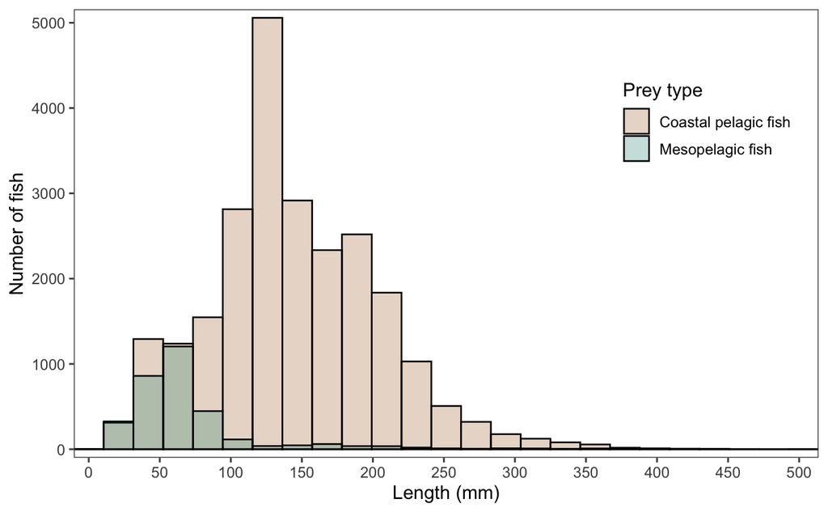

```r
# PLOT histogram of COUNT
ggplot(data=lengths_meso_cps_meso_preds, aes(x=length, group=prey_type))+
  geom_histogram(aes(fill=prey_type), color="black",alpha=0.25, position = "nudge", bins = 25)+ #position nudge doesn't stack the output which is good!
  labs(fill="Prey type", x="Length (mm)", y="Number of fish", size=2 )+
  scale_x_continuous(expand=c(0,0), breaks=seq(0, 500, by=50))+
  scale_y_continuous(expand=c(0,100))+
  scale_fill_manual(values=c("#a6611a", "#018571"), labels=c("Coastal pelagic fish", "Mesopelagic fish"))+
  ggthemes::theme_few()+
  theme(legend.position = c(.85, .75))
```

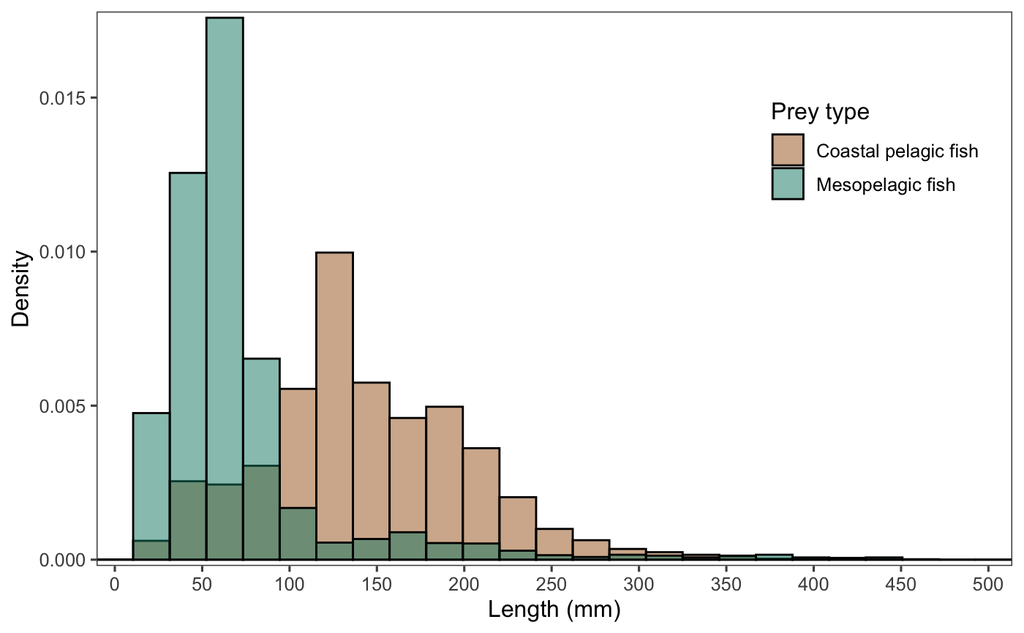

```r
# PLOT histogram DENSITY
ggplot(data=lengths_meso_cps_meso_preds, aes(x=length, group=prey_type))+
  geom_histogram(aes(fill=prey_type, y=..density..), position = "nudge", color="black", bins = 25, alpha=0.5)+ #position nudge doesn't stack the output which is good!
  labs(fill="Prey type", x="Length (mm)", y="Density", size=2 )+
  scale_x_continuous(expand=c(0,0), breaks=seq(0, 500, by=50))+
  scale_y_continuous(expand=c(0.0002,0.0002))+
  scale_fill_manual(values=c("#a6611a", "#018571"), labels=c("Coastal pelagic fish", "Mesopelagic fish"))+
  labs(color="Prey type")+
  ggthemes::theme_few()+
  theme(legend.position = c(.85, .75))


ggsave("./plots/size_freq_meso_cps.pdf")
```

Predator spp with length info [1] “Alopias superciliosus” “Alopias vulpinus” “Anoplopoma fimbria” “Delphinus delphis bairdii” [5] “Delphinus delphis delphis” “Dosidicus gigas” “Isurus oxyrinchus” “Lissodelphis borealis”  
[9] “Merluccius productus” “Oncorhynchus kisutch” “Oncorhynchus mykiss” “Oncorhynchus tshawytscha” [13] “Prionace glauca” ### “Sebastes alutus” “Sebastes flavidus” “Sebastolobus alascanus”  
[17] “Sebastolobus altivelis” “Thunnus alalunga” “Thunnus orientalis” “Xiphias gladius”  
[21] “Zalophus californianus”

Pred spp that ate meso fish [1] “Albatrossia pectoralis” “Alopias superciliosus” “Alopias vulpinus” “Anoplopoma fimbria”  
[5] “Atheresthes stomias” “Bathyraja kincaidii” “Beringraja binoculata” “Beringraja inornata”  
[9] “Beringraja rhina” “Callorhinus ursinus” “Delphinus delphis bairdii” “Delphinus delphis delphis” [13] “Dosidicus gigas” “Gonatidae” “Histioteuthidae” “Isurus oxyrinchus”  
[17] “Lagenorhynchus obliquidens” “Lissodelphis borealis” “Merluccius productus” “Microstomus pacificus”  
[21] “Oncorhynchus kisutch” “Oncorhynchus mykiss” “Oncorhynchus tshawytscha” “Onychoteuthidae”  
[25] “Sebastes alutus” “Sebastes brevispinis” “Sebastes flavidus” “Sebastes mystinus”  
[29] “Sebastes pinniger” “Sebastolobus alascanus” “Sebastolobus altivelis” “Thunnus alalunga”  
[33] “Thunnus orientalis” “Trachurus symmetricus” “Xiphias gladius” “Zalophus californianus”

# PLOT of mesopelagic length distriubtion by family— density plot

```r
ggplot(data=filter(lengths_meso_cps_meso_preds, prey_type=="mesopelagic"), aes(x=length, group=family, color=family))+
  geom_density()+
  labs(color="Prey type", x="Length (mm)", y="Density", size=2 )+
  theme(panel.background = element_blank(),
        legend.key =   element_blank())

ggsave("size_freq_meso_cps.pdf")
# should probably remove those records where only one species represented - can 't do a distribution with 1 value
# the following code removes those values with 3 or less records per family! Next closest min is 6 so should be all good!

# determine which families had less than 10 length values
lengths_meso_cps_meso_preds |>
  group_by(family) |>
  summarise(count=n()) |>
  filter(count<= 10)
```

| family | count |
| --- | --- |
| Anotopteridae | 1 |
| Gonostomatidae | 1 |
| Sternoptychidae | 2 |
| Stomiidae | 6 |

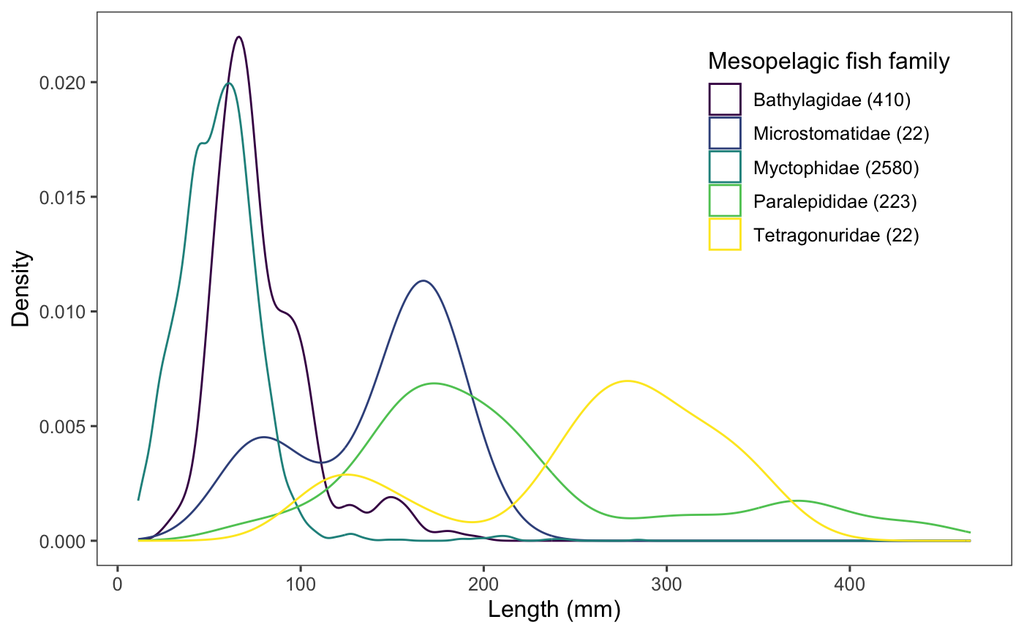

```r
lengths_meso_morethan10 <- lengths_meso_cps_meso_preds |>
                          filter(prey_type=="mesopelagic") |>
                          filter(family != "Sternoptychidae") |>
                          filter(family != "Anotopteridae") |>
                          filter(family != "Gonostomatidae") |>
                          filter(family != "Stomiidae")



# plot length distribution of mesopealgic fish families--- density plot--------
# need to add total # of lengths per spp

ggplot(data=lengths_meso_morethan10, aes(x=length, group=family, color=family))+
  geom_density()+
  scale_color_viridis_d(option="D", labels=c("Bathylagidae (410)", "Microstomatidae (22)", "Myctophidae (2580)", "Paralepididae (223)", "Tetragonuridae (22)"))+
  labs(color="Mesopelagic fish family", x="Length (mm)", y="Density", size=2 )+
  ggthemes::theme_few()+
  theme(legend.position = c(0.8, 0.75))



ggsave("./plots/lengths_meso_families.pdf")
```

#COMBINE our two plots into one succinct plot

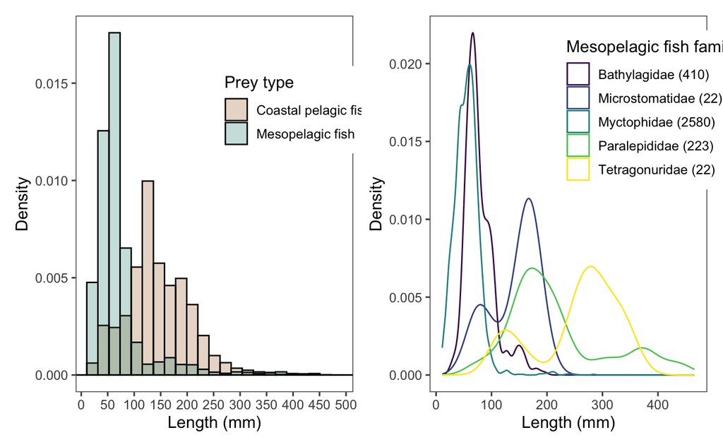

```r
library(patchwork)# to combine multiple plots


#because I want to ensure the plot isn't entirely dominated by the legends I have to play around with formating so leaving originals intact above

#CPS plot
p1= ggplot(data=lengths_meso_cps_meso_preds, aes(x=length, group=prey_type))+
  geom_histogram(aes(fill=prey_type, y=..density..), color="black",alpha=0.25, position = "nudge", bins = 25)+ #position nudge doesn't stack the output which is good!
  labs(fill="Prey type", x="Length (mm)", y="Density", size=2 )+
  scale_x_continuous(expand=c(0,0), breaks=seq(0, 500, by=50))+
  #scale_y_continuous()+
  scale_fill_manual(values=c("#a6611a", "#018571"), labels=c("Coastal pelagic fish", "Mesopelagic fish"))+
  ggthemes::theme_few()+
  theme(legend.position = c(.80, .75))
# Meso family plot
p2= ggplot(data=lengths_meso_morethan10, aes(x=length, group=family, color=family))+
  geom_density()+
  scale_color_viridis_d(option="D", labels=c("Bathylagidae (410)", "Microstomatidae (22)", "Myctophidae (2580)", "Paralepididae (223)", "Tetragonuridae (22)"))+
  labs(color="Mesopelagic fish family", x="Length (mm)", y="Density", size=2 )+
  ggthemes::theme_few()+
  theme(legend.position = c(0.8, 0.75))


p1+p2

p=p1+p2

ggsave(filename = "./plots/length_combined.pdf", plot=p, height=15, width=30, units="cm") # save plot
```

# Calculate range of lengths

```r
p=lengths_meso_cps_meso_preds |>
  filter(prey_type=="cps_fish")

range(p$length) #mesopelagic prey length range: 11-466 mm
```

```
[1]   2.41 505.62
```

```r
                # 2-505 mm
```

# Look at size distribution by mesopealagic family

NOTE: total of 3267 mesopelagic fish with lengths

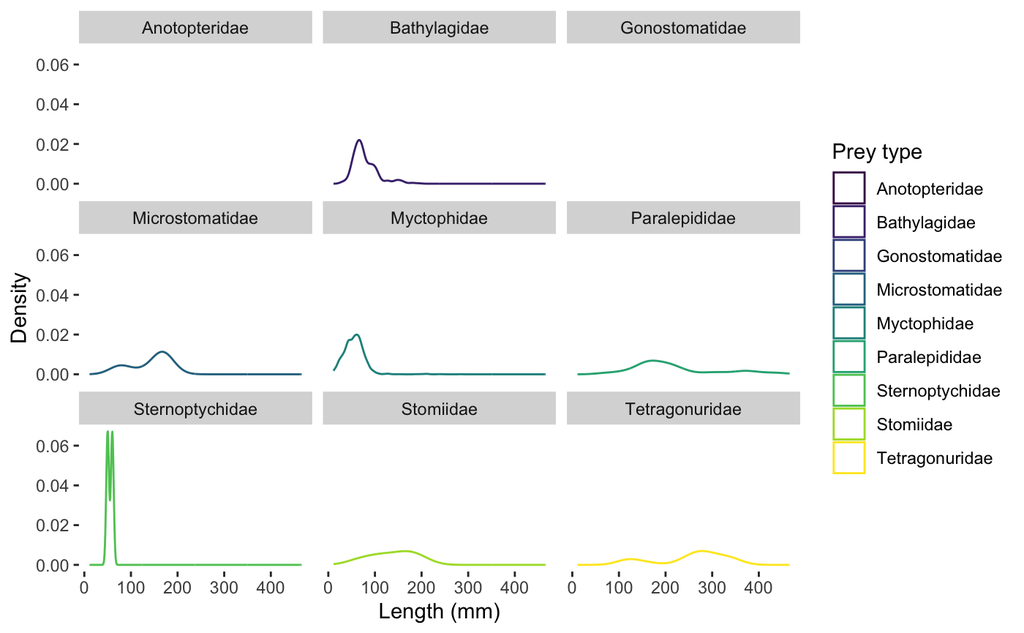

```r
lengths_meso <- lengths_meso_cps |>
                filter(prey_type=="mesopelagic")

# PLOT meso lengths- not very informative!
ggplot(data=lengths_meso, aes(x=length, group=family, color=family))+
  geom_density()+
  scale_color_viridis_d()+
  labs(color="Prey type", x="Length (mm)", y="Density", size=2 )+
  facet_wrap(~family)+
  theme(panel.background = element_blank(),
        legend.key =   element_blank())

ggsave("size_freq_meso_family.pdf")
```

```r
# Create a table of mean lengths per family-- only mesopelagic fishes?
 lengths_meso |>
  group_by(family) |>
  summarise(mean_SL=mean(length), sd_SL= sd(length), n_SL=n()) |>
  mutate(se_SL=sd_SL/sqrt(n_SL)) #calculate se of the mean as standard deviation divided by the sqrt of sample size n
```

| family | mean_SL | sd_SL | n_SL | se_SL |
| --- | --- | --- | --- | --- |
| Anotopteridae | 203.00000 | NA | 1 | NA |
| Bathylagidae | 78.58049 | 27.202253 | 410 | 1.3434235 |
| Gonostomatidae | 195.00000 | NA | 1 | NA |
| Microstomatidae | 141.83909 | 42.047343 | 22 | 8.9645236 |
| Myctophidae | 55.73672 | 23.266151 | 2580 | 0.4580519 |
| Paralepididae | 217.53980 | 91.201746 | 223 | 6.1073206 |
| Sternoptychidae | 55.00000 | 7.071068 | 2 | 5.0000000 |
| Stomiidae | 138.16667 | 48.754145 | 6 | 19.9037964 |
| Tetragonuridae | 255.08023 | 75.756057 | 22 | 16.1512456 |

```r
# Create a table of mean lengths per family- meso and cps
mean_SL_family <- lengths_meso_cps_meso_preds |>
  group_by(family) |>
  summarise(mean_SL=round(mean(length), 2), sd_SL= round(sd(length), 2), n_SL=n()) |>
  mutate(se_SL=round(sd_SL/sqrt(n_SL),2)) #calculate se of the mean as standard deviation divided by the sqrt of sample size n

# export these values as a table
write.csv(mean_SL_family, "lengths_family.csv")
# Separate table for CPS species and Mesopelagic taxa

# Mesopelagic taxa
# Create a table of mean lengths per family- meso and cps
 lengths_meso <-  lengths_meso_cps_meso_preds |>
  filter(prey_type=="mesopelagic") |>
  group_by(prey_scientific_name) |>
  summarise(mean_SL=round(mean(length), 2), sd_SL= round(sd(length), 2), n_SL=n()) |>
  mutate(se_SL=round(sd_SL/sqrt(n_SL),2)) #calculate se of the mean as standard deviation divided by the sqrt of sample size n



# export these values as a table
write.csv(lengths_meso, "lengths_meso.csv")


# CPS taxa (that were consumed by our mesopealgic predator taxa= all but one record :)
# Create a table of mean lengths per family- meso and cps
 lengths_cps <-  lengths_meso_cps_meso_preds |>
  filter(prey_type=="cps_fish") |>
  group_by(prey_scientific_name) |>
  summarise(mean_SL=round(mean(length), 2), sd_SL= round(sd(length),2), n_SL=n()) |>
  mutate(se_SL=round(sd_SL/sqrt(n_SL), 2)) #calculate se of the mean as standard deviation divided by the sqrt of sample size n

 # export these values as a table
write.csv(lengths_cps, "lengths_cps.csv")
```